# Photoquadrats

E. Klein

20210617

last run 2021-09-09 08:15:16

## Goals

This document evaluates the performance of the CoralNet to classify rocky shores main groups from photoquadrats

The analysis comprises:

1. Evaluate the performance of the CoralNet classifier.
2. Compare the classification results of the visually identified quadrats with automatic classification of photoquadrats

## Data

The data is available at [CoralNet_MBON Github repository](https://github.com/gonzalobravoargentina/CoralNet_MBON). The codes for doing the analysis could be found the the Code directory of the same repo.

## CoralNet Classifier performance

### Labels

```r
labelset <- read.csv("../Labelset/labelset_used.csv")

kable(labelset) %>% kable_styling("striped")
```

| Name | Short.Code | Functional.Group | ID.CoralNet | ID.CATAMI | Country |
| --- | --- | --- | --- | --- | --- |
| Bryozoan | BRY | Invertebrates | 1853 | 20000000 | US |
| Cnidaria: Colonial anemones | CNCA | Invertebrates | 4773 | 11500901 | EC |
| Cnidaria: True anemones | CNTR | Invertebrates | 4774 | 11229000 | EC,US |
| Crustacea: Barnacles | CRB | Invertebrates | 357 | 27500000 | AR,EC,CO,US |
| Molluscs: Bivalves | MOB | Invertebrates | 355 | 23199000 | AR,US |
| Molluscs: Gastropods | MOG | Invertebrates | 353 | 24000000 | CO,US |
| Sponge | SP | Invertebrates | 102 | 10000000 | AR |
| Worms: Polychaetes: Tube worms | WPOT | Invertebrates | 361 | 22000901 | AR,CO,EC |
| Substrate: Consolidated (hard) | SC | Substrate | 4114 | 82001001 |  |
| Unclear | Unc | Other | 118 | NA |  |
| Macroalgae: Articulated calcareous | MAA | Algae | 325 | 80300911 | AR,CO,US |
| Macroalgae: Erect coarse branching | MAEC | Algae | 317 | 80300903 | US |
| Macroalgae: Erect fine branching | MAEF | Algae | 313 | 80300907 | US |
| Macroalgae: Encrusting | MAEN | Algae | 321 | 80300926 | AR,EC,CO,US |
| Macroalgae: Filamentous / filiform | MAF | Algae | 309 | 80300930 | AR,EC,CO,US |
| Macroalgae: Globose / saccate | MAG | Algae | 305 | 80300914 | AR |
| Macroalgae: Laminate | MALA | Algae | 301 | 80300918 | US |
| Macroalgae: Large canopy-forming : brown | MALCB | Algae | 299 | 80300902 | AR |
| Macroalgae: Sheet-like / membraneous | MAS | Algae | 294 | 80300922 | AR,EC,US |

Proportion of the labels in the set

```r
df <- read.csv(file.path(dataDir, "annotations.csv"))
dfHuman <- df %>% filter(Comments=='random')
dfRobot <- df %>% filter(Comments=='robot')
# dfSummary <- dfHuman %>% group_by(Label) %>%
#   summarise(nPoints = n(), Countries = paste0(unique(country), collapse = ", ")) %>%
#   mutate(Percent = round(100*nPoints/nrow(df),1)) %>%
#   arrange(-nPoints)
dfSummary <- dfHuman %>% group_by(Label) %>%
  summarise(nPoints = n(), Countries = paste0(unique(country), collapse = ", ")) %>%
  mutate(Percent = round(100*nPoints/nrow(dfHuman),1)) %>%
  arrange(-nPoints)
dfSummary <- left_join(dfSummary, labelset[,c('Name', 'Short.Code')], by=c('Label'='Short.Code')) %>%
  relocate(Name, Label, nPoints, Percent, Countries)

formattable(dfSummary, list(Percent=color_bar("steelblue")))
```

| Name | Label | nPoints | Percent | Countries |
| --- | --- | --- | --- | --- |
| Substrate: Consolidated (hard) | SC | 17814 | 49.2 | ARGENTINA, COLOMBIA, ECUADOR, USA |
| Macroalgae: Erect coarse branching | MAEC | 4766 | 13.2 | USA |
| Macroalgae: Filamentous / filiform | MAF | 2931 | 8.1 | ARGENTINA, COLOMBIA, ECUADOR, USA |
| Macroalgae: Encrusting | MAEN | 2891 | 8.0 | ARGENTINA, COLOMBIA, ECUADOR, USA |
| Molluscs: Bivalves | MOB | 2753 | 7.6 | ARGENTINA, USA |
| Crustacea: Barnacles | CRB | 2196 | 6.1 | ARGENTINA, COLOMBIA, ECUADOR, USA |
| Macroalgae: Sheet-like / membraneous | MAS | 1418 | 3.9 | ARGENTINA, COLOMBIA, USA |
| Macroalgae: Articulated calcareous | MAA | 612 | 1.7 | ARGENTINA, COLOMBIA |
| Worms: Polychaetes: Tube worms | WPOT | 283 | 0.8 | ARGENTINA, COLOMBIA, ECUADOR |
| Unclear | Unc | 179 | 0.5 | ARGENTINA, COLOMBIA, ECUADOR, USA |
| Molluscs: Gastropods | MOG | 145 | 0.4 | COLOMBIA, USA |
| Macroalgae: Large canopy-forming : brown | MALCB | 73 | 0.2 | ARGENTINA |
| Bryozoan | BRY | 66 | 0.2 | USA |
| Macroalgae: Laminate | MALA | 55 | 0.2 | USA |
| Macroalgae: Erect fine branching | MAEF | 9 | 0.0 | USA |
| Cnidaria: True anemones | CNTR | 4 | 0.0 | ECUADOR, USA |
| Cnidaria: Colonial anemones | CNCA | 3 | 0.0 | ECUADOR |
| Macroalgae: Globose / saccate | MAG | 2 | 0.0 | ARGENTINA |

As functional groups the labels and its representation in the data set:

```r
dfFuncGroup <- left_join(df, labelset[,c('Functional.Group', 'Short.Code')], by=c('Label'='Short.Code') )
dfSummary <- dfFuncGroup %>% group_by(Functional.Group) %>%
  summarise(nPoints = n(), Countries = paste0(unique(country), collapse = ", ")) %>%
  mutate(Percent = round(100*nPoints/nrow(df),1)) %>%
  relocate(Functional.Group, nPoints, Percent, Countries) %>%
  arrange(-nPoints)

formattable(dfSummary, list(Percent=color_bar("steelblue")), caption="Functional groups label set")
```

Functional groups label set

| Functional.Group | nPoints | Percent | Countries |
| --- | --- | --- | --- |
| Substrate | 36673 | 50.7 | ARGENTINA, COLOMBIA, ECUADOR, USA |
| Algae | 24736 | 34.2 | ARGENTINA, COLOMBIA, ECUADOR, USA |
| Invertebrates | 10719 | 14.8 | ARGENTINA, COLOMBIA, ECUADOR, USA |
| Other | 272 | 0.4 | ARGENTINA, COLOMBIA, ECUADOR, USA |

### Confusion Matrix

CoralNet uses 7/8 of the data points to train the classification engine and 1/8 as a test set, to calculate the confusion matrix and the classifier accuracy.

#### Full label set

```r
cm <- read.csv(file.path(confmatDir, "New model/confusion_matrix_full_0.csv"), header=FALSE)

##get the Label. It is tricky as the first label has two parenthesis. The valid label is the last one in parenthesis
tblLabels <- str_split( cm[,1], "\\(")
tblLabels <- gsub("\\)", "", unlist(lapply(tblLabels, tail,1)))
nLabels <- nrow(cm)
## modify here to select the first n lables
#nLabels = 7

tt <- as.table(as.matrix(cm[1:nLabels,2:(nLabels+1)]))
rownames(tt) <- tblLabels[1:nLabels]
colnames(tt) <- tblLabels[1:nLabels]

cmm =confusionMatrix(tt)
```

The confusion matrix in numbers:

```r
tbl <- cmm$table
tblDF <- as.data.frame.matrix(tbl)
formattable(tblDF, list(formattable::area(row=TRUE)~color_tile("transparent", "steelblue")))
```

|  | SC | MAEC | MOB | MAEN | MAF | CRB | MAS | MAA | MOG | Unc | WPOT | MALA | MALCB |
| --- | --- | --- | --- | --- | --- | --- | --- | --- | --- | --- | --- | --- | --- |
| SC | 2128 | 8 | 3 | 101 | 27 | 21 | 1 | 2 | 3 | 1 | 3 | 0 | 0 |
| MAEC | 12 | 511 | 2 | 0 | 0 | 13 | 1 | 0 | 0 | 3 | 0 | 0 | 0 |
| MOB | 2 | 0 | 371 | 0 | 0 | 1 | 0 | 0 | 0 | 0 | 0 | 0 | 0 |
| MAEN | 144 | 11 | 1 | 171 | 7 | 6 | 0 | 0 | 1 | 0 | 0 | 0 | 0 |
| MAF | 42 | 2 | 1 | 6 | 238 | 0 | 3 | 1 | 0 | 0 | 3 | 0 | 0 |
| CRB | 22 | 18 | 4 | 5 | 0 | 205 | 0 | 0 | 0 | 0 | 0 | 0 | 0 |
| MAS | 7 | 4 | 0 | 0 | 8 | 2 | 117 | 1 | 0 | 0 | 0 | 0 | 0 |
| MAA | 3 | 0 | 2 | 0 | 5 | 1 | 4 | 38 | 0 | 0 | 0 | 0 | 0 |
| MOG | 6 | 3 | 1 | 0 | 0 | 4 | 0 | 0 | 5 | 0 | 0 | 0 | 0 |
| Unc | 12 | 0 | 0 | 0 | 0 | 0 | 0 | 0 | 0 | 5 | 0 | 0 | 0 |
| WPOT | 1 | 0 | 0 | 1 | 0 | 0 | 0 | 0 | 0 | 0 | 8 | 0 | 0 |
| MALA | 1 | 1 | 0 | 1 | 0 | 0 | 0 | 0 | 0 | 0 | 0 | 1 | 0 |
| MALCB | 0 | 0 | 0 | 0 | 0 | 1 | 0 | 0 | 0 | 0 | 0 | 0 | 2 |

The confusion matrix is (in percentage of row totals):

```r
tbl <- round(100*prop.table(cmm$table, margin = 1),1)
formattable(as.data.frame.matrix(tbl), list(formattable::area(row=TRUE)~color_tile("transparent", "coral")))
```

|  | SC | MAEC | MOB | MAEN | MAF | CRB | MAS | MAA | MOG | Unc | WPOT | MALA | MALCB |
| --- | --- | --- | --- | --- | --- | --- | --- | --- | --- | --- | --- | --- | --- |
| SC | 92.6 | 0.3 | 0.1 | 4.4 | 1.2 | 0.9 | 0.0 | 0.1 | 0.1 | 0.0 | 0.1 | 0 | 0.0 |
| MAEC | 2.2 | 94.3 | 0.4 | 0.0 | 0.0 | 2.4 | 0.2 | 0.0 | 0.0 | 0.6 | 0.0 | 0 | 0.0 |
| MOB | 0.5 | 0.0 | 99.2 | 0.0 | 0.0 | 0.3 | 0.0 | 0.0 | 0.0 | 0.0 | 0.0 | 0 | 0.0 |
| MAEN | 42.2 | 3.2 | 0.3 | 50.1 | 2.1 | 1.8 | 0.0 | 0.0 | 0.3 | 0.0 | 0.0 | 0 | 0.0 |
| MAF | 14.2 | 0.7 | 0.3 | 2.0 | 80.4 | 0.0 | 1.0 | 0.3 | 0.0 | 0.0 | 1.0 | 0 | 0.0 |
| CRB | 8.7 | 7.1 | 1.6 | 2.0 | 0.0 | 80.7 | 0.0 | 0.0 | 0.0 | 0.0 | 0.0 | 0 | 0.0 |
| MAS | 5.0 | 2.9 | 0.0 | 0.0 | 5.8 | 1.4 | 84.2 | 0.7 | 0.0 | 0.0 | 0.0 | 0 | 0.0 |
| MAA | 5.7 | 0.0 | 3.8 | 0.0 | 9.4 | 1.9 | 7.5 | 71.7 | 0.0 | 0.0 | 0.0 | 0 | 0.0 |
| MOG | 31.6 | 15.8 | 5.3 | 0.0 | 0.0 | 21.1 | 0.0 | 0.0 | 26.3 | 0.0 | 0.0 | 0 | 0.0 |
| Unc | 70.6 | 0.0 | 0.0 | 0.0 | 0.0 | 0.0 | 0.0 | 0.0 | 0.0 | 29.4 | 0.0 | 0 | 0.0 |
| WPOT | 10.0 | 0.0 | 0.0 | 10.0 | 0.0 | 0.0 | 0.0 | 0.0 | 0.0 | 0.0 | 80.0 | 0 | 0.0 |
| MALA | 25.0 | 25.0 | 0.0 | 25.0 | 0.0 | 0.0 | 0.0 | 0.0 | 0.0 | 0.0 | 0.0 | 25 | 0.0 |
| MALCB | 0.0 | 0.0 | 0.0 | 0.0 | 0.0 | 33.3 | 0.0 | 0.0 | 0.0 | 0.0 | 0.0 | 0 | 66.7 |

The general accuracy of the classifier is **87.36%**.

In %:

```r
round(100*cmm$overall, 2)
```

```
      Accuracy          Kappa  AccuracyLower  AccuracyUpper   AccuracyNull AccuracyPValue
         87.36          81.22          86.33          88.33          54.71           0.00
 McnemarPValue
           NaN
```

The classifier produces a set of five “guesses” for the labels and a confidence for each guess (analogous to a certainty percent) for each points, and assign to the point the label with highest confidence. The variability of the confidence of the first suggestion is a good indicator of the performance of the classifier for each of the labels.

```r
dfLabelSugg <- dfRobot %>% group_by(Label) %>%
  summarise(n = n(), min = min(Machine.confidence.1), mean = round(mean(Machine.confidence.1),1),
            max = max(Machine.confidence.1), p75 = quantile(Machine.confidence.1, 0.75),
            p95 = quantile(Machine.confidence.1, 0.95)
  )
dfLabelSugg <- left_join(dfLabelSugg, labelset[,c('Name', 'Short.Code')], by=c('Label'='Short.Code')) %>%
  arrange(-mean) %>%
  relocate(Name)


formattable(dfLabelSugg, list(mean=color_bar("steelblue")))
```

| Name | Label | n | min | mean | max | p75 | p95 |
| --- | --- | --- | --- | --- | --- | --- | --- |
| Molluscs: Bivalves | MOB | 2652 | 29 | 89.9 | 91 | 91 | 91.0 |
| Substrate: Consolidated (hard) | SC | 18859 | 24 | 89.8 | 93 | 93 | 93.0 |
| Macroalgae: Erect coarse branching | MAEC | 4993 | 21 | 89.5 | 91 | 91 | 91.0 |
| Macroalgae: Sheet-like / membraneous | MAS | 1353 | 26 | 87.5 | 91 | 91 | 91.0 |
| Crustacea: Barnacles | CRB | 2277 | 20 | 87.3 | 91 | 91 | 91.0 |
| Macroalgae: Filamentous / filiform | MAF | 2898 | 25 | 86.2 | 92 | 92 | 92.0 |
| Macroalgae: Large canopy-forming : brown | MALCB | 67 | 31 | 85.7 | 91 | 91 | 91.0 |
| Macroalgae: Articulated calcareous | MAA | 509 | 24 | 84.6 | 92 | 92 | 92.0 |
| Molluscs: Gastropods | MOG | 101 | 27 | 82.1 | 91 | 91 | 91.0 |
| Worms: Polychaetes: Tube worms | WPOT | 239 | 29 | 80.3 | 88 | 88 | 88.0 |
| Macroalgae: Encrusting | MAEN | 2126 | 19 | 80.1 | 94 | 92 | 93.0 |
| Unclear | Unc | 93 | 20 | 77.0 | 91 | 90 | 91.0 |
| Macroalgae: Laminate | MALA | 33 | 22 | 52.6 | 73 | 65 | 71.4 |

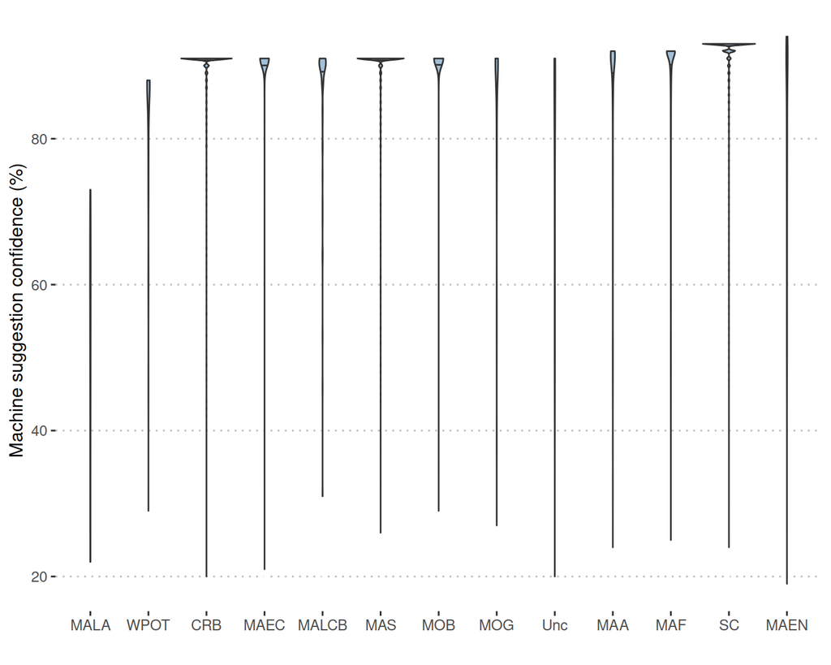

```r
pp = ggplot(dfRobot, aes(x=fct_reorder(Label, Machine.confidence.1, max ), y=Machine.confidence.1, group=Label))
pp + geom_violin(draw_quantiles = 0.5, fill="steelblue", alpha=0.5) +
  labs(x="", y="Machine suggestion confidence (%)") +
  theme_pubclean()
```

#### Functional group labels

Analysis of the performance of the classifier on **Functional Groups**

```r
cm <- read.csv(file.path(confmatDir, "New model/confusion_matrix_func_0.csv"), header=FALSE)


##get the Label. It is tricky as the first label has two parenthesis. The valid label is the last one in parenthesis
tblLabels <- str_split( cm[,1], "\\(")
tblLabels <- gsub("\\)", "", unlist(lapply(tblLabels, tail,1)))
nLabels <- nrow(cm)
## modify here to select the first n lables
#nLabels = 7

tt <- as.table(as.matrix(cm[1:nLabels,2:(nLabels+1)]))
rownames(tt) <- tblLabels[1:nLabels]
colnames(tt) <- tblLabels[1:nLabels]

cmm =confusionMatrix(tt)
```

The confusion matrix in numbers:

```r
tbl <- cmm$table
formattable(as.data.frame.matrix(tbl), list(formattable::area(row=T)~color_tile("transparent", "steelblue")))
```

|  | Hard Substrate | Algae | Other Invertebrates | Other |
| --- | --- | --- | --- | --- |
| Hard Substrate | 2128 | 139 | 30 | 1 |
| Algae | 209 | 1133 | 33 | 3 |
| Other Invertebrates | 31 | 27 | 599 | 0 |
| Other | 12 | 0 | 0 | 5 |

The confusion matrix is (in percentage of row totals):

```r
tbl <- round(100*prop.table(cmm$table, margin = 1),1)
formattable(as.data.frame.matrix(tbl), list(formattable::area(row=TRUE)~color_tile("transparent", "coral")))
```

|  | Hard Substrate | Algae | Other Invertebrates | Other |
| --- | --- | --- | --- | --- |
| Hard Substrate | 92.6 | 6.0 | 1.3 | 0.0 |
| Algae | 15.2 | 82.2 | 2.4 | 0.2 |
| Other Invertebrates | 4.7 | 4.1 | 91.2 | 0.0 |
| Other | 70.6 | 0.0 | 0.0 | 29.4 |

The general accuracy of the classifier is **88.85%**.

In %:

```r
round(100*cmm$overall, 2)
```

```
      Accuracy          Kappa  AccuracyLower  AccuracyUpper   AccuracyNull AccuracyPValue
         88.85          81.21          87.88          89.77          54.71           0.00
 McnemarPValue
           NaN
```

## Photoquadrats vs Robot

This compares the classification of the 100 point grid labels from the photo quadrats to the output of the robot. We will use the same Bray-Curtis approach as we’re interested in the composition of the community. If the robot is good enough, the BC distance must remain close to zero in the majority of the quadrats.

We will use the labels that contribute in total up to 95% of all the records. The reason behind this is that with few rare labels used in the training of the robot, the classification accuracy of these labels are expected to be low, hence producing an artificially higher Bray-Curtis distance.

```r
## get fotoquadrat human community data
CM_Human <- read.csv(file.path(humanDir, "percent_covers.csv"))
## there is an additional row summarising everything. Delete it
CM_Human <- head(CM_Human, -1)
## the new data has a Image.Name instead on Name. Need to be fixed. Also there is a new column named "Points"
CM_Human = CM_Human %>% dplyr::select(Id = Image.ID, Name = Image.name, -Points, everything())

colnames(CM_Human)[1:2] = c("Id", "Name")

dfHuman <- CM_Human %>% pivot_longer(cols = 5:23, names_to = 'Label', values_to = 'Cover')
humanLabels <- dfHuman %>%
  group_by(Label) %>% summarise(n=sum(Cover)) %>%
  arrange(-n) %>%
  mutate(acum=cumsum(n), acumP = acum/sum(n))
humanLabels95 <- humanLabels$Label[humanLabels$acumP<=0.96]

## make community matrix from robot
CM_Robot <- dfRobot %>% group_by(Name, Label) %>% summarise(n = n())
CM_Robot$Name <- gsub("JPG", "jpg", CM_Robot$Name)
robotLabels <- CM_Robot %>% group_by(Label) %>% summarise(n=sum(n)) %>%
  arrange(-n) %>%
  mutate(acum=cumsum(n), acumP = acum/sum(n))
robotLabels95 <- robotLabels$Label[robotLabels$acumP<=0.96]

## intersect the set of both labels
labels95 <- intersect(humanLabels95, robotLabels95)

## make it wide
CM_Robot95 <- CM_Robot %>% pivot_wider(id_cols = 'Name', names_from = 'Label', values_from = 'n') %>%
  dplyr::select(Name, contains(labels95))
## replace NA by zero
CM_Robot95[is.na(CM_Robot95)] <- 0
CM_Robot95$Name <- gsub("_robot", "", CM_Robot95$Name)

## select human labels that match the top 95% of the robot's labels
CM_Human95 <- CM_Human %>% dplyr::select(Name, contains(labels95))
CM_Human95$Name <- gsub("_human", "", CM_Human95$Name)
```

Generate the BC table. For each photo (Name) build a two-row community matrix (row1: Human, row2: Robot), and calculate the BC distance.

```r
## calculate BC index
BC_RH <- data.frame(Name=character(), BC=numeric())
for (i in 1:nrow(CM_Human95)){
  robotIndex <- which(CM_Robot95$Name==CM_Human95$Name[i])
  if (length(robotIndex) > 0 ){
    CM_one <- bind_rows(CM_Human95[i,-1], CM_Robot95[robotIndex,-1])
    CM_one[is.na(CM_one)] <- 0
    BC_RH <- bind_rows(BC_RH,
                    data.frame(Name = CM_Human95$Name[i],
                               BC = as.numeric(vegdist(CM_one, na.rm = T))))
  }else {
    print(paste0("NOT FOUND in Robot: ", CM_Visual$Name[i]))
  }
}

## fix the mess US did with the Human and Robot Name (that sounds deep, very deep!)
BC_RH$Country <- str_sub(BC_RH$Name,1,2)
BC_RH$Site <- ifelse(BC_RH$Country=='US', str_sub(BC_RH$Name,3,6),str_split(BC_RH$Name, "_", simplify = T)[,3] )
BC_RH$Strata <- ifelse(BC_RH$Country=='US', str_split(BC_RH$Name, "_", simplify = T)[,3],
                            str_split(BC_RH$Name, "_", simplify = T)[,4])
BC_RH$Strata <- recode_factor(BC_RH$Strata, low="LT", mid="MT", high="HT")


## recode locations
BC_RH$Site <- recode_factor(BC_RH$Site, PC="Punta Cuevas", PE="Punta Este", PL="Punta Lobos",
                            LM="La Mancora", LV="La Ventana", PV="Playa Verde",
                            CD="Charles Darwin Station", RA="Ratonera", TO="Tortuga Bay",
                            MAMH="MAMH", MAPH="MAPH", MECH="MECH", MEGS="MEGS")
BC_RH$Strata <- recode_factor(BC_RH$Strata, LT="LOWTIDE", MT="MIDTIDE", HT="HIGHTIDE")
```

Plot the BC distances by strata and country:

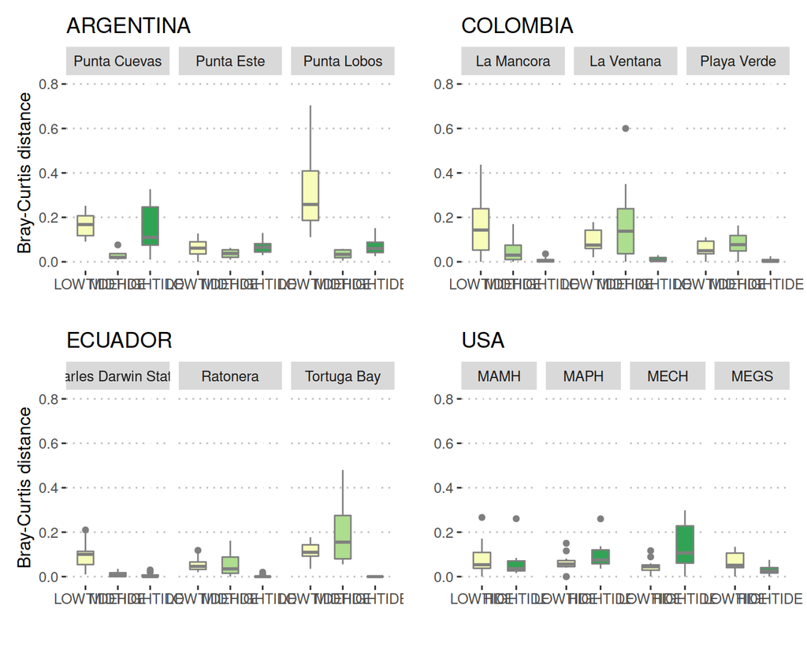

```r
strataColor = c(LOWTIDE="#f7fcb9", MIDTIDE="#addd8e", HIGHTIDE="#31a354")

pp_ARG <- ggplot(BC_RH %>% filter(Country=="AR"), aes(Strata, BC))
pp_ARG <- pp_ARG + geom_boxplot(width=0.5, aes(fill=Strata), colour="grey50") +
  ylim(0,0.8) +
  scale_color_manual(values = strataColor, aesthetics = 'fill') +
  labs(title="ARGENTINA", x="", y="Bray-Curtis distance") +
  facet_grid(~Site) +
  theme_pubclean() +
  theme(legend.position = 'none')

pp_COL <- ggplot(BC_RH %>% filter(Country=="CO"), aes(Strata, BC))
pp_COL <- pp_COL + geom_boxplot(width=0.5, aes(fill=Strata), colour="grey50") +
  ylim(0,0.8) +
  scale_color_manual(values = strataColor, aesthetics = 'fill') +
  labs(title="COLOMBIA", x="", y=" ") +
  facet_grid(~Site) +
  theme_pubclean() +
  theme(legend.position = 'none')

pp_ECU <- ggplot(BC_RH %>% filter(Country=="EC"), aes(Strata, BC))
pp_ECU <- pp_ECU + geom_boxplot(width=0.5, aes(fill=Strata), colour="grey50") +
  ylim(0,0.8) +
  scale_color_manual(values = strataColor, aesthetics = 'fill') +
  labs(title="ECUADOR", x="", y="Bray-Curtis distance") +
  facet_grid(~Site) +
  theme_pubclean() +
  theme(legend.position = 'none')

pp_USA <- ggplot(BC_RH %>% filter(Country=="US"), aes(Strata, BC))
pp_USA <- pp_USA + geom_boxplot(width=0.5, aes(fill=Strata), colour="grey50") +
  ylim(0,0.8) +
  scale_color_manual(values = strataColor, aesthetics = 'fill') +
  labs(title="USA", x="", y=" ") +
  facet_grid(~Site) +
  theme_pubclean() +
  theme(legend.position = 'none')

(pp_ARG + pp_COL) / (pp_ECU + pp_USA)
```

Apply a GMM nested model

It is a bit tricky as it is not balanced: US has four (4) sites, the rest three (3), and also sampled the HT and LT but not MT. So the model is strata nested in country with quadrat aas random factor

```r
BC_RH <- BC_RH %>% group_by(Country, Site, Strata) %>% mutate(Quadrat=1:n())

model = glmer(BC ~ (Country/Strata) + (1|Quadrat), data=BC_RH, family=binomial)
summary(model)
```

```
Generalized linear mixed model fit by maximum likelihood (Laplace Approximation) ['glmerMod']
 Family: binomial  ( logit )
Formula: BC ~ (Country/Strata) + (1 | Quadrat)
   Data: BC_RH

     AIC      BIC   logLik deviance df.resid
    41.5     88.2     -8.8     17.5      350

Scaled residuals:
     Min       1Q   Median       3Q      Max
       0        1  1996454  4589629 32212255

Random effects:
 Groups  Name        Variance  Std.Dev.
 Quadrat (Intercept) 3.278e-19 5.726e-10
Number of obs: 362, groups:  Quadrat, 18

Fixed effects:
                           Estimate Std. Error z value Pr(>|z|)
(Intercept)              -3.367e+00  1.017e+00  -3.311 0.000931 ***
CountryCO                -4.275e+03  1.215e+07   0.000 0.999719
CountryEC                -4.101e+02  1.225e+07   0.000 0.999973
CountryUS                -1.881e+02  9.895e+06   0.000 0.999985
CountryAR:StrataMIDTIDE  -3.207e+01  9.036e+06   0.000 0.999997
CountryCO:StrataMIDTIDE   4.275e+03  1.215e+07   0.000 0.999719
CountryEC:StrataMIDTIDE   3.739e+02  1.733e+07   0.000 0.999983
CountryAR:StrataHIGHTIDE -3.638e+01  1.225e+07   0.000 0.999998
CountryCO:StrataHIGHTIDE  4.091e+03  1.726e+07   0.000 0.999811
CountryEC:StrataHIGHTIDE -7.107e+02  1.733e+07   0.000 0.999967
CountryUS:StrataHIGHTIDE  4.369e+01  1.399e+07   0.000 0.999998
---
Signif. codes:  0 '***' 0.001 '**' 0.01 '*' 0.05 '.' 0.1 ' ' 1

Correlation of Fixed Effects:
            (Intr) CntrCO CntrEC CntrUS CAR:SM CCO:SM CEC:SM CAR:SH CCO:SH CEC:SH
CountryCO    0.000
CountryEC    0.000  0.000
CountryUS    0.000  0.000  0.000
CAR:SMIDTID  0.000  0.000  0.000  0.000
CCO:SMIDTID  0.000 -1.000  0.000  0.000  0.000
CEC:SMIDTID  0.000  0.000 -0.707  0.000  0.000  0.000
CAR:SHIGHTI  0.000  0.000  0.000  0.000  0.000  0.000  0.000
CCO:SHIGHTI  0.000 -0.704  0.000  0.000  0.000  0.704  0.000  0.000
CEC:SHIGHTI  0.000  0.000 -0.707  0.000  0.000  0.000  0.500  0.000  0.000
CUS:SHIGHTI  0.000  0.000  0.000 -0.707  0.000  0.000  0.000  0.000  0.000  0.000
fit warnings:
fixed-effect model matrix is rank deficient so dropping 1 column / coefficient
convergence code: 0
boundary (singular) fit: see ?isSingular
```

```r
testCountry = glht(model, linfct = mcp("Country" = "Tukey"))
summary(testCountry)
```

```
     Simultaneous Tests for General Linear Hypotheses

Multiple Comparisons of Means: Tukey Contrasts


Fit: glmer(formula = BC ~ (Country/Strata) + (1 | Quadrat), data = BC_RH,
    family = binomial)

Linear Hypotheses:
               Estimate Std. Error z value Pr(>|z|)
CO - AR == 0    -4274.8 12151502.1       0        1
EC - AR == 0     -410.1 12252346.2       0        1
US - AR == 0     -188.1  9894662.2       0        1
EC - CO == 0     3864.7 17256274.0       0        1
US - CO == 0     4086.7 15670460.9       0        1
US - EC == 0      222.0 15748788.1       0        1
(Adjusted p values reported -- single-step method)
```

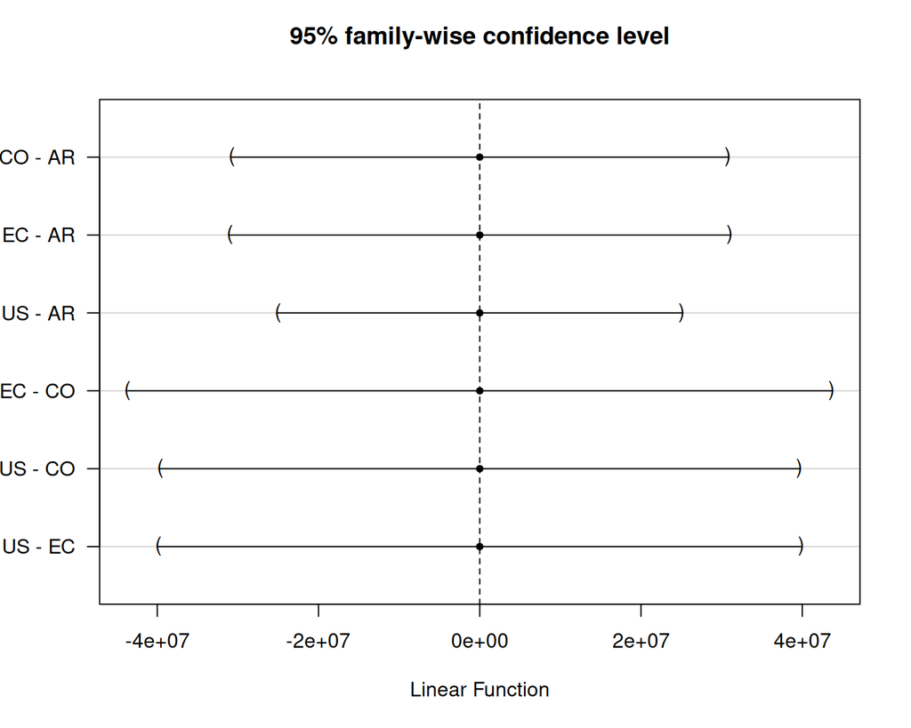

```r
plot(confint(testCountry))
```

There is no sig differences between the estimates of community composition between strata or countries.

```r
BCmean <- round(mean(BC_RH$BC),3)
BCn <- nrow(BC_RH)
BCsd <- sd(BC_RH$BC)
BCmargin <- qt(0.975,df=BCn-1)*BCsd/sqrt(BCn)
BCupper <- round(BCmean + BCmargin, 3)
BClower <- round(BCmean - BCmargin, 3)
```

AS demonstrated, the classifier is insensitive to the variability produced by Country and Strata, being equally efficient no matter the source of the quadrat. **In general, the difference between the classifier and the visual estimate of the community cover of a mean quadrat is 0.074 with a 95% confidence interval of [0.064 - 0.084]**

## Similarity with visual

The idea here is to test if there is differences between the quadrat surveyed in the field and analysed visually with the result of the classifier over the same quadrats.

As we don’t label every point in the quadrat in the field, it is not possible to make a point-to-point comparison. However, if we estimate the cover of each of the categories in each of the quadrats and do the same with the result of the classifier, it will be possible to calculate a distance metric that represent how different are the estimates. AS we are dealing with counts (number of points in each category), a Bray-Curtis distance is appropriate. Here the hypothesis is that if both methods produce the same result, the BC distance must be zero.

For each quadrat it is possible to make a community matrix: 2 rows, visual and machine estimates, and n columns, being n the number of labels). Then we can calculate the BC distance comparing the two methods.

Then we can compare the BC distances (as proportions) using a generalized nested mixed models.

Method:

1. bind visual cover estimates from all sites, except USA, as the USA photoquadrats does not coincide with the quadrats used for visual estimates

```r
## bind visual data

CM_Visual <- bind_rows(read.csv("../Visual_quadrats/argentina_visual.csv"),
                     read.csv("../Visual_quadrats/colombia_visual.csv"),
                     read.csv("../Visual_quadrats/galapagos_visual.csv"))

CM_VisualLong <- CM_Visual %>% pivot_longer(cols = 21:33, names_to = 'Label', values_to = 'Count' )


CM_Robot <- CM_Robot %>% pivot_wider(id_cols = "Name", names_from = "Label", values_from = "n")

## match the Names with visual (dropping USA quadrats)
visualQD <- unique(CM_Visual$Name)
CM_Robot = CM_Robot[CM_Robot$Name %in% visualQD,]
```

#### Full Label Set

We will use the only the labels produced by the classifier as the label set. We will drop not used labels from the visual and recalculate the cover.

```r
## calculate BC index
BC <- data.frame(Country=character(), Site=character(), Strata=character(), BC=numeric())
for (i in 1:nrow(CM_Visual)){
  robotIndex <- which(CM_Robot$Name==CM_Visual$Name[i])
  if (length(robotIndex) > 0 ){
    CM_one <- bind_rows(CM_Visual[i,21:33], CM_Robot[robotIndex,2:13])
    CM_one[is.na(CM_one)] <- 0
    BC <- bind_rows(BC,
                    data.frame(Country = CM_Visual$country[i],
                               Site = CM_Visual$site[i],
                               Strata = CM_Visual$strata[i],
                               BC = as.numeric(vegdist(CM_one, na.rm = T))))
  }else {
    print(paste0("NOT FOUND in Robot: ", CM_Visual$Name[i]))
  }
}
BC$Strata <- factor(BC$Strata, levels = c("LOWTIDE", "MIDTIDE", "HIGHTIDE"))
```

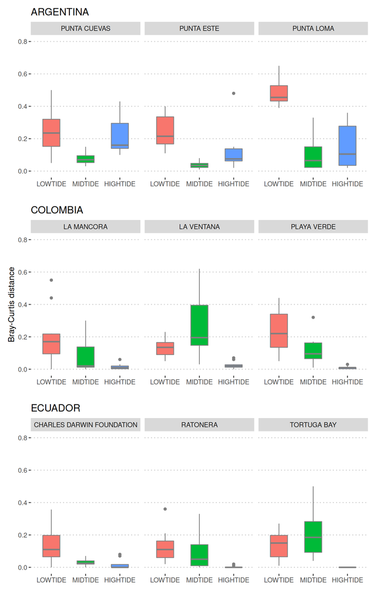

```r
pp_ARG <- ggplot(BC %>% filter(Country=="ARGENTINA"), aes(Strata, BC))
pp_ARG <- pp_ARG + geom_boxplot(width=0.5, aes(fill=Strata), colour="grey50") +
  ylim(0,0.8) +
  labs(title="ARGENTINA", x="", y=" ") +
  facet_grid(~Site) +
  theme_pubclean() +
  theme(legend.position = 'none')

pp_COL <- ggplot(BC %>% filter(Country=="COLOMBIA"), aes(Strata, BC))
pp_COL <- pp_COL + geom_boxplot(width=0.5, aes(fill=Strata), colour="grey50") +
  ylim(0,0.8) +
  labs(title="COLOMBIA", x="", y="Bray-Curtis distance") +
  facet_grid(~Site) +
  theme_pubclean() +
  theme(legend.position = 'none')

pp_ECU <- ggplot(BC %>% filter(Country=="ECUADOR"), aes(Strata, BC))
pp_ECU <- pp_ECU + geom_boxplot(width=0.5, aes(fill=Strata), colour="grey50") +
  ylim(0,0.8) +
  labs(title="ECUADOR", x="", y=" ") +
  facet_grid(~Site) +
  theme_pubclean() +
  theme(legend.position = 'none')

pp_ARG / pp_COL / pp_ECU
```

#### Reduced Label Set

Let’s try to reduce the number of labels to the most representative ones. It makes sense as the infrequent labels have poorly accuracy in the classifier as the number of training points is very low.

This is the number of points and accumulated % per label:

```r
tt = table(dfRobot$Label)
sort(tt, decreasing = T)
```

```
   SC  MAEC   MAF   MOB   CRB  MAEN   MAS   MAA  WPOT   MOG   Unc MALCB  MALA
18859  4993  2898  2652  2277  2126  1353   509   239   101    93    67    33
```

and the accumulated %. Let’s pick the labels that accumulate up to 95% of the point

```r
labelAcum <- CM_VisualLong %>% group_by(Label) %>%
  summarise(n=sum(Count, na.rm=T)) %>%
  arrange(-n) %>%
  mutate(nPercent = round(100*n/sum(n), 2), pAcum = cumsum(nPercent))

kable(labelAcum, caption = "% of points per label, accumulated") %>%
  kable_styling("striped", full_width = FALSE)
```

% of points per label, accumulated

| Label | n | nPercent | pAcum |
| --- | --- | --- | --- |
| SC | 16661 | 61.71 | 61.71 |
| MAF | 2680 | 9.93 | 71.64 |
| MOB | 2659 | 9.85 | 81.49 |
| MAEN | 2566 | 9.50 | 90.99 |
| MAA | 1131 | 4.19 | 95.18 |
| MAS | 643 | 2.38 | 97.56 |
| WPOT | 297 | 1.10 | 98.66 |
| CRB | 177 | 0.66 | 99.32 |
| MOG | 54 | 0.20 | 99.52 |
| MAG | 47 | 0.17 | 99.69 |
| MALCB | 45 | 0.17 | 99.86 |
| CNTR | 30 | 0.11 | 99.97 |
| CNCA | 9 | 0.03 | 100.00 |

```r
labels95 <- labelAcum$Label[labelAcum$pAcum<=96]

labels95
```

```
[1] "SC"   "MAF"  "MOB"  "MAEN" "MAA"
```

and repeat the BC analysis, including only **SC,MAF,MOB,MAEN,MAA**…

```r
## Filter robot labels using selected visual labels
CM_Robot5 <- CM_Robot %>% dplyr::select(Name, contains(labels95))
CM_Visual5 <- CM_Visual %>% dplyr::select(Name, country, site, strata, contains(labels95))

## calculate BC index
BC <- data.frame(Country=character(), Site=character(), Strata=character(), BC=numeric())
for (i in 1:nrow(CM_Visual)){
  robotIndex <- which(CM_Robot5$Name==CM_Visual$Name[i])
  if (length(robotIndex) > 0 ){
    CM_one <- bind_rows(CM_Visual5[i,5:ncol(CM_Visual5)], CM_Robot5[robotIndex,2:ncol(CM_Robot5)])
    CM_one[is.na(CM_one)] <- 0
    BC <- bind_rows(BC,
                    data.frame(Country = CM_Visual$country[i],
                               Site = CM_Visual$site[i],
                               Strata = CM_Visual$strata[i],
                               BC = as.numeric(vegdist(CM_one, na.rm = T))))
  }else {
    print(paste0("NOT FOUND in Robot: ", CM_Visual$Name[i]))
  }
}
BC$Strata <- factor(BC$Strata, levels = c("LOWTIDE", "MIDTIDE", "HIGHTIDE"))
```

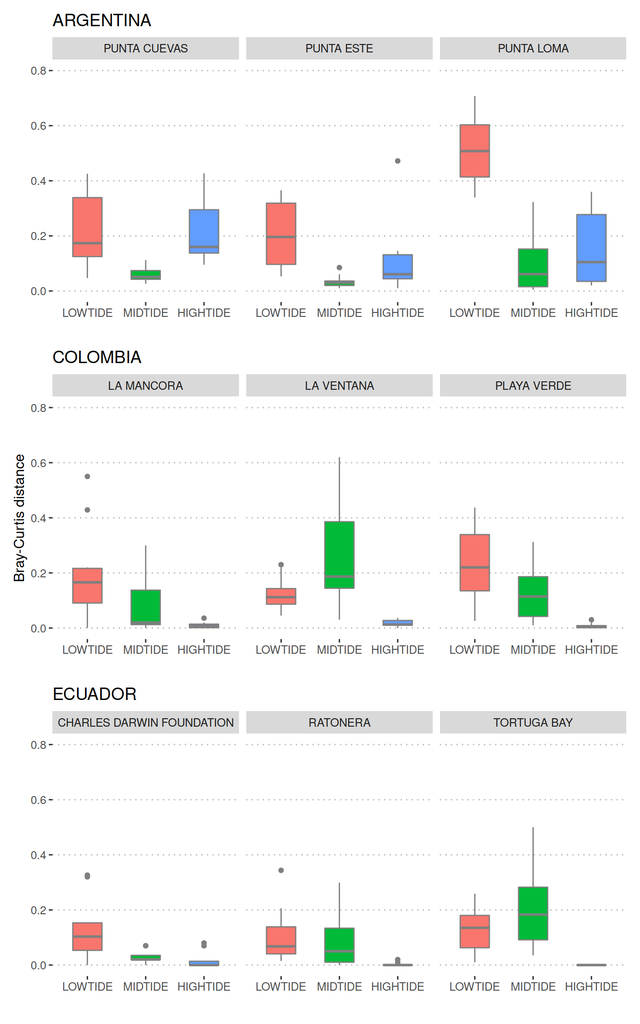

```r
pp_ARG <- ggplot(BC %>% filter(Country=="ARGENTINA"), aes(Strata, BC))
pp_ARG <- pp_ARG + geom_boxplot(width=0.5, aes(fill=Strata), colour="grey50") +
  ylim(0,0.8) +
  labs(title="ARGENTINA", x="", y=" ") +
  facet_grid(~Site) +
  theme_pubclean() +
  theme(legend.position = 'none')

pp_COL <- ggplot(BC %>% filter(Country=="COLOMBIA"), aes(Strata, BC))
pp_COL <- pp_COL + geom_boxplot(width=0.5, aes(fill=Strata), colour="grey50") +
  ylim(0,0.8) +
  labs(title="COLOMBIA", x="", y="Bray-Curtis distance") +
  facet_grid(~Site) +
  theme_pubclean() +
  theme(legend.position = 'none')

pp_ECU <- ggplot(BC %>% filter(Country=="ECUADOR"), aes(Strata, BC))
pp_ECU <- pp_ECU + geom_boxplot(width=0.5, aes(fill=Strata), colour="grey50") +
  ylim(0,0.8) +
  labs(title="ECUADOR", x="", y=" ") +
  facet_grid(~Site) +
  theme_pubclean() +
  theme(legend.position = 'none')

pp_ARG / pp_COL / pp_ECU
```

Description of the BC values

```r
BCsummary <- BC %>% group_by(Country, Site, Strata) %>%
  summarize(n = n(), BCmean = mean(BC), BCsd = sd(BC), BCmin = min(BC), BCmax = max(BC),
            BCq25 = quantile(BC, 0.25), BCmedian = median(BC), BCq75 = quantile(BC, 0.75))

kable(BCsummary, digits=2) %>% kable_styling("striped", full_width = FALSE)
```

| Country | Site | Strata | n | BCmean | BCsd | BCmin | BCmax | BCq25 | BCmedian | BCq75 |
| --- | --- | --- | --- | --- | --- | --- | --- | --- | --- | --- |
| ARGENTINA | PUNTA CUEVAS | LOWTIDE | 10 | 0.22 | 0.14 | 0.05 | 0.43 | 0.13 | 0.17 | 0.34 |
| ARGENTINA | PUNTA CUEVAS | MIDTIDE | 10 | 0.06 | 0.03 | 0.03 | 0.11 | 0.04 | 0.05 | 0.07 |
| ARGENTINA | PUNTA CUEVAS | HIGHTIDE | 10 | 0.21 | 0.12 | 0.10 | 0.43 | 0.14 | 0.16 | 0.30 |
| ARGENTINA | PUNTA ESTE | LOWTIDE | 10 | 0.20 | 0.13 | 0.05 | 0.37 | 0.10 | 0.20 | 0.32 |
| ARGENTINA | PUNTA ESTE | MIDTIDE | 10 | 0.03 | 0.02 | 0.01 | 0.09 | 0.02 | 0.03 | 0.04 |
| ARGENTINA | PUNTA ESTE | HIGHTIDE | 10 | 0.11 | 0.13 | 0.01 | 0.47 | 0.04 | 0.06 | 0.13 |
| ARGENTINA | PUNTA LOMA | LOWTIDE | 10 | 0.51 | 0.12 | 0.34 | 0.71 | 0.41 | 0.51 | 0.60 |
| ARGENTINA | PUNTA LOMA | MIDTIDE | 10 | 0.10 | 0.10 | 0.01 | 0.32 | 0.02 | 0.06 | 0.15 |
| ARGENTINA | PUNTA LOMA | HIGHTIDE | 10 | 0.15 | 0.13 | 0.02 | 0.36 | 0.04 | 0.11 | 0.28 |
| COLOMBIA | LA MANCORA | LOWTIDE | 10 | 0.20 | 0.17 | 0.00 | 0.55 | 0.09 | 0.17 | 0.22 |
| COLOMBIA | LA MANCORA | MIDTIDE | 10 | 0.08 | 0.11 | 0.00 | 0.30 | 0.01 | 0.02 | 0.14 |
| COLOMBIA | LA MANCORA | HIGHTIDE | 10 | 0.01 | 0.01 | 0.00 | 0.04 | 0.00 | 0.01 | 0.01 |
| COLOMBIA | LA VENTANA | LOWTIDE | 10 | 0.12 | 0.06 | 0.05 | 0.23 | 0.09 | 0.11 | 0.14 |
| COLOMBIA | LA VENTANA | MIDTIDE | 10 | 0.26 | 0.20 | 0.03 | 0.62 | 0.14 | 0.19 | 0.39 |
| COLOMBIA | LA VENTANA | HIGHTIDE | 10 | 0.02 | 0.01 | 0.00 | 0.04 | 0.01 | 0.01 | 0.03 |
| COLOMBIA | PLAYA VERDE | LOWTIDE | 10 | 0.23 | 0.14 | 0.03 | 0.44 | 0.14 | 0.22 | 0.34 |
| COLOMBIA | PLAYA VERDE | MIDTIDE | 10 | 0.13 | 0.10 | 0.01 | 0.31 | 0.04 | 0.11 | 0.19 |
| COLOMBIA | PLAYA VERDE | HIGHTIDE | 10 | 0.01 | 0.01 | 0.00 | 0.03 | 0.00 | 0.01 | 0.01 |
| ECUADOR | CHARLES DARWIN FOUNDATION | LOWTIDE | 10 | 0.13 | 0.11 | 0.00 | 0.33 | 0.05 | 0.10 | 0.15 |
| ECUADOR | CHARLES DARWIN FOUNDATION | MIDTIDE | 10 | 0.03 | 0.02 | 0.00 | 0.07 | 0.02 | 0.02 | 0.04 |
| ECUADOR | CHARLES DARWIN FOUNDATION | HIGHTIDE | 10 | 0.02 | 0.03 | 0.00 | 0.08 | 0.00 | 0.00 | 0.01 |
| ECUADOR | RATONERA | LOWTIDE | 10 | 0.11 | 0.10 | 0.02 | 0.34 | 0.04 | 0.07 | 0.14 |
| ECUADOR | RATONERA | MIDTIDE | 10 | 0.08 | 0.10 | 0.00 | 0.30 | 0.01 | 0.05 | 0.13 |
| ECUADOR | RATONERA | HIGHTIDE | 10 | 0.00 | 0.01 | 0.00 | 0.02 | 0.00 | 0.00 | 0.00 |
| ECUADOR | TORTUGA BAY | LOWTIDE | 10 | 0.13 | 0.08 | 0.01 | 0.26 | 0.06 | 0.14 | 0.18 |
| ECUADOR | TORTUGA BAY | MIDTIDE | 10 | 0.20 | 0.15 | 0.04 | 0.50 | 0.09 | 0.18 | 0.28 |
| ECUADOR | TORTUGA BAY | HIGHTIDE | 10 | 0.00 | 0.00 | 0.00 | 0.00 | 0.00 | 0.00 | 0.00 |

#### Nested model

Let’s create additional variables: Quadrat and Site2 which are the sites coded as A, B, C

```r
BC$Quadrat <- rep(1:10, 27)
BC$Site2 <- rep(c(rep("A",30), rep("B", 30), rep("C", 30)), 3)
```

and fit a binomial nested model with BC as dependent variables and Country and Strata as fixed factors and Site and Quadrat as random factors.

```r
library(lme4)
library(multcomp)

par(mar=c(7,7,7,7))
par(oma=c(1,1,1,1))

#model = glmer(BC ~ Country + Site2 + Strata + (Country/Site2/Strata) + (1|Quadrat), data=BC, family=binomial)
model = glmer(BC ~ Country +  Strata + (1|Site2) + (1|Quadrat), data=BC, family=binomial)
summary(model)
```

```
Generalized linear mixed model fit by maximum likelihood (Laplace Approximation) ['glmerMod']
 Family: binomial  ( logit )
Formula: BC ~ Country + Strata + (1 | Site2) + (1 | Quadrat)
   Data: BC

     AIC      BIC   logLik deviance df.resid
    70.0     95.2    -28.0     56.0      263

Scaled residuals:
     Min       1Q   Median       3Q      Max
       0        0        1  2331441 33554432

Random effects:
 Groups  Name        Variance  Std.Dev.
 Quadrat (Intercept) 1.999e-16 1.414e-08
 Site2   (Intercept) 2.409e-17 4.908e-09
Number of obs: 270, groups:  Quadrat, 10; Site2, 3

Fixed effects:
                  Estimate Std. Error z value Pr(>|z|)
(Intercept)     -1.950e+00  5.240e-01  -3.721 0.000198 ***
CountryCOLOMBIA -5.564e-01  7.609e-01  -0.731 0.464686
CountryECUADOR  -4.590e+02  7.195e+06   0.000 0.999949
StrataMIDTIDE   -1.175e+00  8.397e-01  -1.399 0.161701
StrataHIGHTIDE  -3.235e+01  3.940e+06   0.000 0.999993
---
Signif. codes:  0 '***' 0.001 '**' 0.01 '*' 0.05 '.' 0.1 ' ' 1

Correlation of Fixed Effects:
            (Intr) CCOLOM CECUAD SMIDTI
CntCOLOMBIA -0.566
CntrECUADOR  0.000  0.000
StrtMIDTIDE -0.433  0.016  0.000
StrHIGHTIDE  0.000  0.000 -0.183  0.000
convergence code: 0
boundary (singular) fit: see ?isSingular
```

```r
testStrata = glht(model, linfct = mcp("Strata" = "Tukey"))
summary(testStrata)
```

```
     Simultaneous Tests for General Linear Hypotheses

Multiple Comparisons of Means: Tukey Contrasts


Fit: glmer(formula = BC ~ Country + Strata + (1 | Site2) + (1 | Quadrat),
    data = BC, family = binomial)

Linear Hypotheses:
                          Estimate Std. Error z value Pr(>|z|)
MIDTIDE - LOWTIDE == 0  -1.175e+00  8.397e-01  -1.399    0.297
HIGHTIDE - LOWTIDE == 0 -3.235e+01  3.940e+06   0.000    1.000
HIGHTIDE - MIDTIDE == 0 -3.117e+01  3.940e+06   0.000    1.000
(Adjusted p values reported -- single-step method)
```

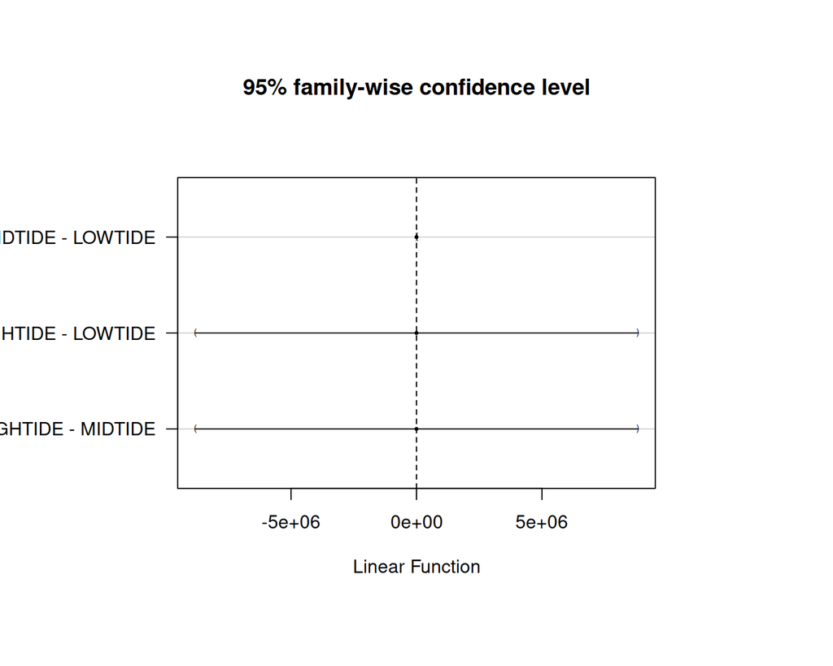

```r
plot(confint(testStrata), cex=0.5)
```

```r
testCountry = glht(model, linfct = mcp("Country" = "Tukey"))
summary(testCountry)
```

```
     Simultaneous Tests for General Linear Hypotheses

Multiple Comparisons of Means: Tukey Contrasts


Fit: glmer(formula = BC ~ Country + Strata + (1 | Site2) + (1 | Quadrat),
    data = BC, family = binomial)

Linear Hypotheses:
                            Estimate Std. Error z value Pr(>|z|)
COLOMBIA - ARGENTINA == 0 -5.564e-01  7.609e-01  -0.731    0.713
ECUADOR - ARGENTINA == 0  -4.590e+02  7.195e+06   0.000    1.000
ECUADOR - COLOMBIA == 0   -4.585e+02  7.195e+06   0.000    1.000
(Adjusted p values reported -- single-step method)
```

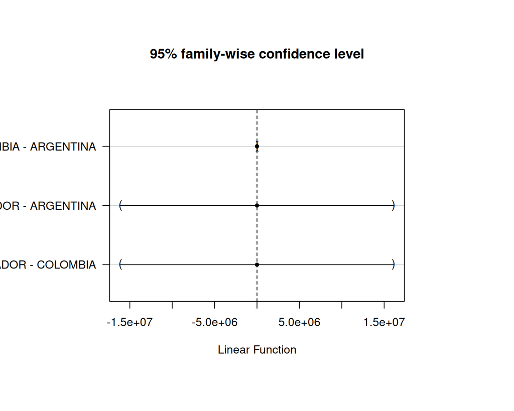

```r
plot(confint(testCountry))
```

```r
BCmean <- round(mean(BC$BC),3)
BCn <- nrow(BC)
BCsd <- sd(BC$BC)
BCmargin <- qt(0.975,df=BCn-1)*BCsd/sqrt(BCn)
BCupper <- round(BCmean + BCmargin, 3)
BClower <- round(BCmean - BCmargin, 3)
```

AS demonstrated, the classifier is insensitive to the variability produced by Country, Site and Strata, being equally efficient no matter the source of the quadrat. **In general, the difference between the classifier and the visual estimate of the community cover of a mean quadrat is 0.124 with a 95% confidence interval of [0.106 - 0.142]**

## Similarity with visual: Functional groups

Group the labels into functional groups:

According to Gonza’s code the correspondence of `labels` to `funcGroup` is:

| Functional Group | Label |
| --- | --- |
| `ALGAE` | MAF,MAEN,MAA,MAG,MAS,MALCB,MAEC,MAEF,MALA |
| `SUBSTRATE` | SC |
| `INVERTEBRATES` | CRB,MOB,CNTR,WPOT,MOG,CNCA,BRY,CR,MOCH |

```r
## Re-classify labels into functional groups labels

CM_Robot_FC <- CM_Robot %>% group_by(Name) %>%
  summarise(ALGAE = sum(MAF,MAEN,MAA,MAS,MALCB,MAEC, na.rm=T),
            SUBSTRATE = SC,
            INVERTEBRATES = sum(CRB,MOB,WPOT,MOG, na.rm=T))

CM_Visual_FC <- CM_Visual %>% group_by(Name) %>%
  summarise(ALGAE = sum(MAF,MAEN,MAA,MAG,MAS,MALCB, na.rm=T),
            SUBSTRATE = SC,
            INVERTEBRATES = sum(CRB,MOB,CNTR,WPOT,MOG,CNCA, na.rm = T))

CM_Human_FC <- CM_Human %>% group_by(Name) %>%
  summarise(ALGAE = sum(MAF,MAEN,MAA,MAS,MALCB,MAEC, na.rm=T),
            SUBSTRATE = SC,
            INVERTEBRATES = sum(CRB,MOB,WPOT,MOG, na.rm=T))
```

## Figure 2: new proposal

I propose to plot the cover estimates from field (visual) along with estimated of the robot for the main labels only, the same included in the GMM analysis.

With labels that represent up to 95% of all records:

```r
## make long DFs
CM_Visual5_long <- CM_Visual5 %>% pivot_longer(cols = 5:9, names_to = "label", values_to = 'Cover')
CM_Visual5_long$source <- "visual"

CM_Robot5_long <- CM_Robot5 %>% pivot_longer(cols = 2:6, names_to = "label", values_to = 'Cover')
CM_Robot5_long$source <- "robot"

CM_Human5_long <- CM_Human95 %>% pivot_longer(cols = 2:7, names_to = "label", values_to = 'Cover')
CM_Human5_long$source <- "human"

CM_compare <- bind_rows(CM_Visual5_long, CM_Robot5_long, CM_Human5_long)

CM_compare$countryCode <- str_sub(CM_compare$Name,1,2)
CM_compare$siteCode <- ifelse(CM_compare$countryCode=='US', str_sub(CM_compare$Name,3,6),str_split(CM_compare$Name, "_", simplify = T)[,3] )
CM_compare$strataCode <- ifelse(CM_compare$countryCode=='US', str_split(CM_compare$Name, "_", simplify = T)[,3],
                            str_split(CM_compare$Name, "_", simplify = T)[,4])
CM_compare$strataCode <- recode_factor(CM_compare$strataCode, low="LT", mid="MT", high="HT")


#
#
# CM_compare$countryCode <- str_split(CM_compare$Name, "_", simplify = T)[,1]
# CM_compare$siteCode <- str_split(CM_compare$Name, "_", simplify = T)[,3]
# CM_compare$strataCode <- str_split(CM_compare$Name, "_", simplify = T)[,4]
# CM_compare$strataCode <- factor(CM_compare$strataCode, levels = c("LT", "MT", "HT"))
```

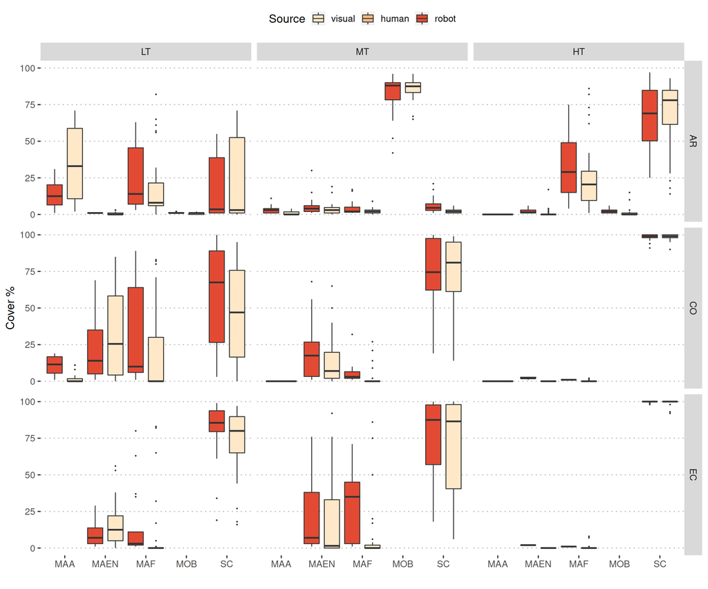

```r
sourceColor <- c(visual="#fee8c8", human="#fdbb84", robot="#e34a33")

pp <- ggplot(CM_compare %>% filter(source != "human"), aes(label, Cover))
pp + geom_boxplot(position=position_dodge(1), aes(fill=source), outlier.size = 0.3) +
  labs(x="", y="Cover %") +
  scale_colour_manual("Source", values = sourceColor, aesthetics = 'fill') +
  facet_grid(countryCode~strataCode) +
  theme_pubclean(base_size=14)
```

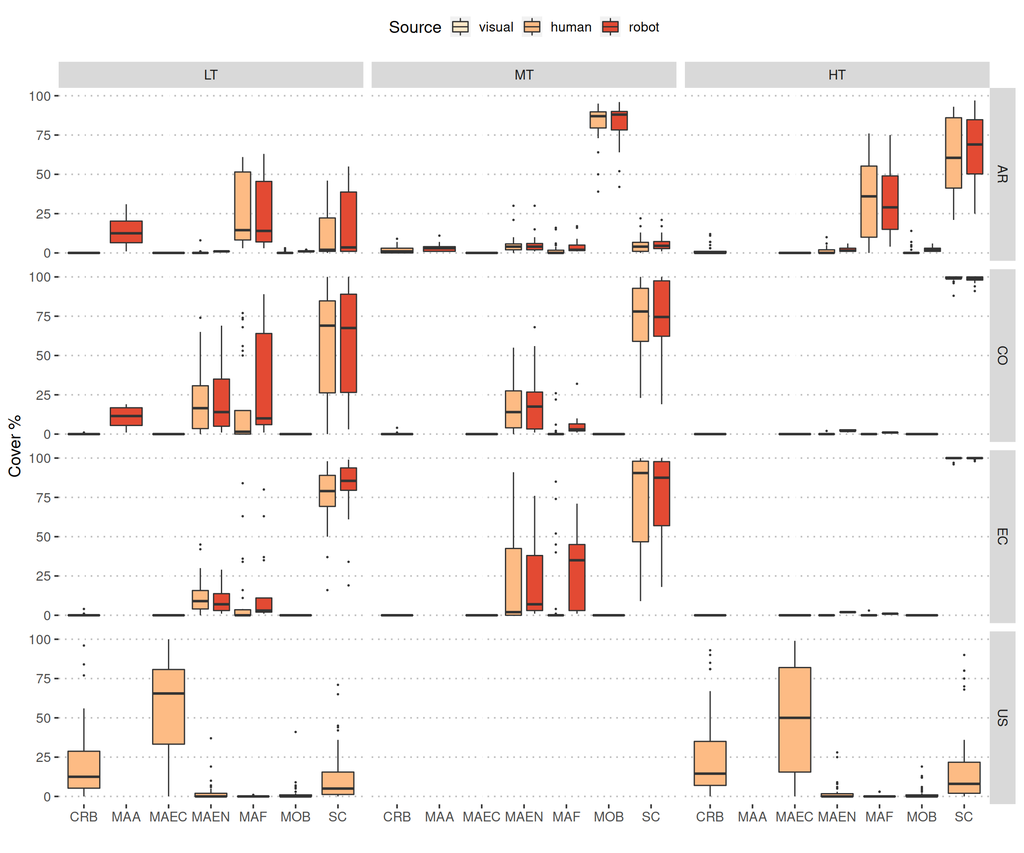

```r
pp <- ggplot(CM_compare %>% filter(source != "visual"), aes(label, Cover))
pp + geom_boxplot(position=position_dodge(1), aes(fill=source), outlier.size = 0.3) +
  labs(x="", y="Cover %") +
  scale_colour_manual("Source", values = sourceColor, aesthetics = 'fill') +
  facet_grid(countryCode~strataCode) +
  theme_pubclean(base_size=14)
```

With Functional Groups

```r
CM_Visual_FC_long <- CM_Visual_FC %>% pivot_longer(cols = 2:4, names_to = "label", values_to = "Cover")
CM_Visual_FC_long$source <- "visual"

CM_Robot_FC_long <- CM_Robot_FC %>% pivot_longer(cols = 2:4, names_to = "label", values_to = "Cover")
CM_Robot_FC_long$source <- "robot"

CM_Human_FC_long <- CM_Human_FC %>% pivot_longer(cols = 2:4, names_to = "label", values_to = "Cover")
CM_Human_FC_long$source <- "human"

CM_compare_FC <- bind_rows(CM_Visual_FC_long, CM_Robot_FC_long, CM_Human_FC_long)

CM_compare_FC$countryCode <- str_sub(CM_compare_FC$Name,1,2)
CM_compare_FC$siteCode <- ifelse(CM_compare_FC$countryCode=='US', str_sub(CM_compare_FC$Name,3,6),str_split(CM_compare_FC$Name, "_", simplify = T)[,3] )
CM_compare_FC$strataCode <- ifelse(CM_compare_FC$countryCode=='US', str_split(CM_compare_FC$Name, "_", simplify = T)[,3],
                            str_split(CM_compare_FC$Name, "_", simplify = T)[,4])
CM_compare_FC$strataCode[CM_compare_FC$strataCode=='high'] <- "HT"
CM_compare_FC$strataCode[CM_compare_FC$strataCode=='low'] <- "LT"


# CM_compare_FC$countryCode <- str_split(CM_compare_FC$Name, "_", simplify = T)[,1]
# CM_compare_FC$siteCode <- str_split(CM_compare_FC$Name, "_", simplify = T)[,3]
# CM_compare_FC$strataCode <- str_split(CM_compare_FC$Name, "_", simplify = T)[,4]
CM_compare_FC$strataCode <- factor(CM_compare_FC$strataCode, levels = c("LT", "MT", "HT"))
```

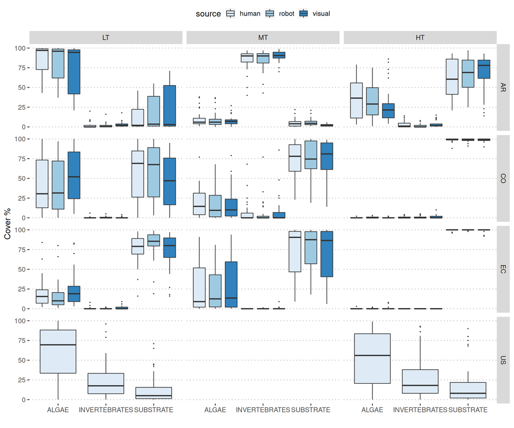

```r
pp <- ggplot(CM_compare_FC, aes(label, Cover))
pp + geom_boxplot(position=position_dodge(1), aes(fill=source), outlier.size = 0.3) +
  labs(x="", y="Cover %") +
  scale_colour_brewer(palette = "Blues", aesthetics = 'fill') +
  facet_grid(countryCode~strataCode) +
  theme_pubclean(base_size=14)
```

Let’s apply a nested model to test if there is difference between the cover estimates from human and robot for each label. Site and strata are random factors

Robot vs Visual

```r
CM_compare$Cover[is.na(CM_compare$Cover)] <- 0

#model <- glmer(Cover/100 ~ source + label +  (1|countryCode:siteCode:strataCode), data=CM_compare, family=binomial)
model <- glmer(Cover/100 ~ countryCode*source*label + (1|siteCode:strataCode), data=CM_compare, subset=source!='human' , family=binomial)
summary(model)
```

```
Generalized linear mixed model fit by maximum likelihood (Laplace Approximation) ['glmerMod']
 Family: binomial  ( logit )
Formula: Cover/100 ~ countryCode * source * label + (1 | siteCode:strataCode)
   Data: CM_compare
 Subset: source != "human"

     AIC      BIC   logLik deviance df.resid
    1390     1573     -664     1328     2669

Scaled residuals:
    Min      1Q  Median      3Q     Max
-2.8267 -0.2551 -0.0255  0.1270  7.4449

Random effects:
 Groups              Name        Variance  Std.Dev.
 siteCode:strataCode (Intercept) 3.993e-06 0.001998
Number of obs: 2700, groups:  siteCode:strataCode, 27

Fixed effects:
                                      Estimate Std. Error z value Pr(>|z|)
(Intercept)                            -3.5221     0.6314  -5.578 2.44e-08 ***
countryCodeCO                          -2.4336     2.1701  -1.121 0.262105
countryCodeEC                         -17.2343  3388.9652  -0.005 0.995942
sourcevisual                            1.6871     0.7017   2.404 0.016195 *
labelMAEN                              -2.0615     1.8376  -1.122 0.261934
labelMAF                                1.5441     0.7091   2.178 0.029436 *
labelMOB                                2.8130     0.6701   4.198 2.69e-05 ***
labelSC                                 2.5367     0.6744   3.761 0.000169 ***
countryCodeCO:sourcevisual             -2.0084     3.2769  -0.613 0.539939
countryCodeEC:sourcevisual             -0.8471  4055.0259   0.000 0.999833
countryCodeCO:labelMAEN                 5.2850     2.8073   1.883 0.059757 .
countryCodeEC:labelMAEN                19.1938  3388.9657   0.006 0.995481
countryCodeCO:labelMAF                  1.9302     2.2292   0.866 0.386553
countryCodeEC:labelMAF                 16.1703  3388.9653   0.005 0.996193
countryCodeCO:labelMOB                 -4.6427     5.6130  -0.827 0.408163
countryCodeEC:labelMOB                  3.6404  3391.6333   0.001 0.999144
countryCodeCO:labelSC                   5.1065     2.2022   2.319 0.020404 *
countryCodeEC:labelSC                  20.7307  3388.9653   0.006 0.995119
sourcevisual:labelMAEN                 -3.4456     4.5439  -0.758 0.448281
sourcevisual:labelMAF                  -1.7697     0.8410  -2.104 0.035356 *
sourcevisual:labelMOB                  -1.6637     0.7697  -2.161 0.030658 *
sourcevisual:labelSC                   -1.2315     0.7721  -1.595 0.110693
countryCodeCO:sourcevisual:labelMAEN    4.3308     5.5863   0.775 0.438193
countryCodeEC:sourcevisual:labelMAEN    4.0180  4055.0284   0.001 0.999209
countryCodeCO:sourcevisual:labelMAF     2.1029     3.3561   0.627 0.530926
countryCodeEC:sourcevisual:labelMAF     1.1179  4055.0259   0.000 0.999780
countryCodeCO:sourcevisual:labelMOB     1.6882     8.5770   0.197 0.843958
countryCodeEC:sourcevisual:labelMOB     7.5771  4057.2586   0.002 0.998510
countryCodeCO:sourcevisual:labelSC      1.0050     3.3146   0.303 0.761731
countryCodeEC:sourcevisual:labelSC     -0.5101  4055.0259   0.000 0.999900
---
Signif. codes:  0 '***' 0.001 '**' 0.01 '*' 0.05 '.' 0.1 ' ' 1
convergence code: 0
unable to evaluate scaled gradient
Model failed to converge: degenerate  Hessian with 3 negative eigenvalues
failure to converge in 10000 evaluations
```

Robot vs Human

```r
#model <- glmer(Cover/100 ~ source + label +  (1|countryCode:siteCode:strataCode), data=CM_compare, family=binomial)
model <- glmer(Cover/100 ~ countryCode*source*label + (1|siteCode) + (1|strataCode), data=CM_compare, subset=source!='visual' , family=binomial)
summary(model)
```

```
Generalized linear mixed model fit by maximum likelihood (Laplace Approximation) ['glmerMod']
 Family: binomial  ( logit )
Formula: Cover/100 ~ countryCode * source * label + (1 | siteCode) + (1 |      strataCode)
   Data: CM_compare
 Subset: source != "visual"

     AIC      BIC   logLik deviance df.resid
  1514.2   1767.0   -716.1   1432.2     3481

Scaled residuals:
    Min      1Q  Median      3Q     Max
-2.9857 -0.2301 -0.0105  0.1122  9.7785

Random effects:
 Groups     Name        Variance Std.Dev.
 siteCode   (Intercept) 0.002683 0.05179
 strataCode (Intercept) 0.093882 0.30640
Number of obs: 3522, groups:  siteCode, 13; strataCode, 3

Fixed effects:
                                      Estimate Std. Error z value Pr(>|z|)
(Intercept)                         -5.551e+00  1.602e+00  -3.466 0.000528 ***
countryCodeCO                       -2.481e+00  5.730e+00  -0.433 0.665021
countryCodeEC                       -4.186e+00  1.299e+01  -0.322 0.747188
countryCodeUS                        3.729e+00  1.619e+00   2.303 0.021270 *
sourcerobot                          5.421e-01  3.460e-01   1.567 0.117191
labelMAA                            -1.816e+00  3.414e+00  -0.532 0.594682
labelMAEC                           -1.636e+01  5.643e+03  -0.003 0.997687
labelMAEN                           -1.227e+00  3.335e+00  -0.368 0.712863
labelMAF                             4.082e+00  1.613e+00   2.531 0.011374 *
labelMOB                             4.780e+00  1.607e+00   2.975 0.002935 **
labelSC                              4.090e+00  1.613e+00   2.536 0.011209 *
countryCodeCO:sourcerobot           -3.641e-01  5.516e-01  -0.660 0.509117
countryCodeEC:sourcerobot            3.015e-02  6.237e-01   0.048 0.961447
countryCodeCO:labelMAA               3.728e+00  6.776e+00   0.550 0.582198
countryCodeEC:labelMAA              -1.792e+01  1.866e+05   0.000 0.999923
countryCodeCO:labelMAEC             -2.984e+00  8.732e+04   0.000 0.999973
countryCodeEC:labelMAEC              1.349e+01  5.643e+03   0.002 0.998093
countryCodeUS:labelMAEC              1.840e+01  5.643e+03   0.003 0.997399
countryCodeCO:labelMAEN              6.359e+00  6.452e+00   0.986 0.324345
```

[output cut: 13 more lines]

```
sourcerobot:labelMOB                -5.341e-01  4.676e-01  -1.142 0.253326
countryCodeCO:sourcerobot:labelMAEN  7.889e-01  4.362e+00   0.181 0.856480
countryCodeEC:sourcerobot:labelMAEN -1.423e+00  4.416e+00  -0.322 0.747284
countryCodeCO:sourcerobot:labelMAF   8.971e-01  8.728e-01   1.028 0.304032
countryCodeEC:sourcerobot:labelMAF   1.863e-01  9.772e-01   0.191 0.848764
countryCodeCO:sourcerobot:labelMOB  -1.994e+01  3.043e+05   0.000 0.999948
countryCodeEC:sourcerobot:labelMOB  -7.498e+00  4.493e+02  -0.017 0.986686
---
Signif. codes:  0 '***' 0.001 '**' 0.01 '*' 0.05 '.' 0.1 ' ' 1
fit warnings:
fixed-effect model matrix is rank deficient so dropping 17 columns / coefficients
convergence code: 0
unable to evaluate scaled gradient
Model failed to converge: degenerate  Hessian with 2 negative eigenvalues
failure to converge in 10000 evaluations
```

For the functional groups

Robot vs visual

```r
#model <- glmer(Cover/100 ~ source + label +  (1|countryCode:siteCode:strataCode), data=CM_compare, family=binomial)
model <- glmer(Cover/100 ~ source + label + (1|siteCode:strataCode), data=CM_compare_FC, subset=source!='human' , family=binomial)
summary(model)
```

```
Generalized linear mixed model fit by maximum likelihood (Laplace Approximation) ['glmerMod']
 Family: binomial  ( logit )
Formula: Cover/100 ~ source + label + (1 | siteCode:strataCode)
   Data: CM_compare_FC
 Subset: source != "human"

     AIC      BIC   logLik deviance df.resid
  1603.9   1630.8   -797.0   1593.9     1609

Scaled residuals:
    Min      1Q  Median      3Q     Max
-1.4347 -0.3597 -0.3014  0.4845  2.7927

Random effects:
 Groups              Name        Variance Std.Dev.
 siteCode:strataCode (Intercept) 1.08e-10 1.039e-05
Number of obs: 1614, groups:  siteCode:strataCode, 27

Fixed effects:
                   Estimate Std. Error z value Pr(>|z|)
(Intercept)        -1.37061    0.12405 -11.049  < 2e-16 ***
sourcevisual       -0.03151    0.12466  -0.253      0.8
labelINVERTEBRATES -0.67455    0.17337  -3.891 9.99e-05 ***
labelSUBSTRATE      2.12218    0.14188  14.958  < 2e-16 ***
---
Signif. codes:  0 '***' 0.001 '**' 0.01 '*' 0.05 '.' 0.1 ' ' 1

Correlation of Fixed Effects:
            (Intr) srcvsl lINVER
sourcevisul -0.498
lINVERTEBRA -0.539  0.001
lbSUBSTRATE -0.652 -0.012  0.471
convergence code: 0
boundary (singular) fit: see ?isSingular
```

Robot vs Human

```r
model <- glmer(Cover/100 ~ source + label + (1|siteCode:strataCode), data=CM_compare_FC, subset=source!='visual' , family=binomial)
summary(model)
```

```
Generalized linear mixed model fit by maximum likelihood (Laplace Approximation) ['glmerMod']
 Family: binomial  ( logit )
Formula: Cover/100 ~ source + label + (1 | siteCode:strataCode)
   Data: CM_compare_FC
 Subset: source != "visual"

     AIC      BIC   logLik deviance df.resid
  2042.8   2070.5  -1016.4   2032.8     1885

Scaled residuals:
    Min      1Q  Median      3Q     Max
-1.1954 -0.4353 -0.3187  0.5983  2.7227

Random effects:
 Groups              Name        Variance Std.Dev.
 siteCode:strataCode (Intercept) 0        0
Number of obs: 1890, groups:  siteCode:strataCode, 35

Fixed effects:
                   Estimate Std. Error z value Pr(>|z|)
(Intercept)         -1.0916     0.1027 -10.631  < 2e-16 ***
sourcerobot          0.1180     0.1096   1.076    0.282
labelINVERTEBRATES  -0.9804     0.1534  -6.393 1.63e-10 ***
labelSUBSTRATE       1.3644     0.1216  11.224  < 2e-16 ***
---
Signif. codes:  0 '***' 0.001 '**' 0.01 '*' 0.05 '.' 0.1 ' ' 1

Correlation of Fixed Effects:
            (Intr) srcrbt lINVER
sourcerobot -0.471
lINVERTEBRA -0.518 -0.006
lbSUBSTRATE -0.668  0.022  0.440
convergence code: 0
boundary (singular) fit: see ?isSingular
```